# Tugas 1 visual

## 1.4.1 Latihan

1.Bermain-mainlah dengan estetika warna, bentuk, dan ukuran. Apa yang terjadi ketika Anda memetakannya ke nilai kontinu? Bagaimana dengan nilai kategorikal? Apa yang terjadi ketika Anda menggunakan lebih dari satu estetika dalam sebuah grafik?

2.Apa yang terjadi jika Anda memetakan variabel kontinu ke bentuk? Mengapa? Apa yang terjadi jika Anda memetakan trans ke bentuk? Mengapa?

3.Bagaimana hubungannya sistem penggerak dengan efisiensi bahan bakar? Bagaimana hubungannya sistem penggerak dengan ukuran dan kelas mesin?

## 1.5 Pembuatan Faset

Teknik lain untuk menampilkan variabel kategorikal tambahan pada plot adalah faceting. Faceting membuat tabel grafik dengan membagi data menjadi beberapa subset dan menampilkan grafik yang sama untuk setiap subset.

Ada dua jenis faceting: grid dan wrapped. Wrapped adalah yang paling berguna, jadi kita akan membahasnya di sini, dan Anda bisa mempelajari tentang grid faceting nanti. Untuk melakukan faceting pada plot, Anda cukup menambahkan spesifikasi faceting dengan `facet_wrap()`, yang mengambil nama variabel yang diawali dengan `~`.

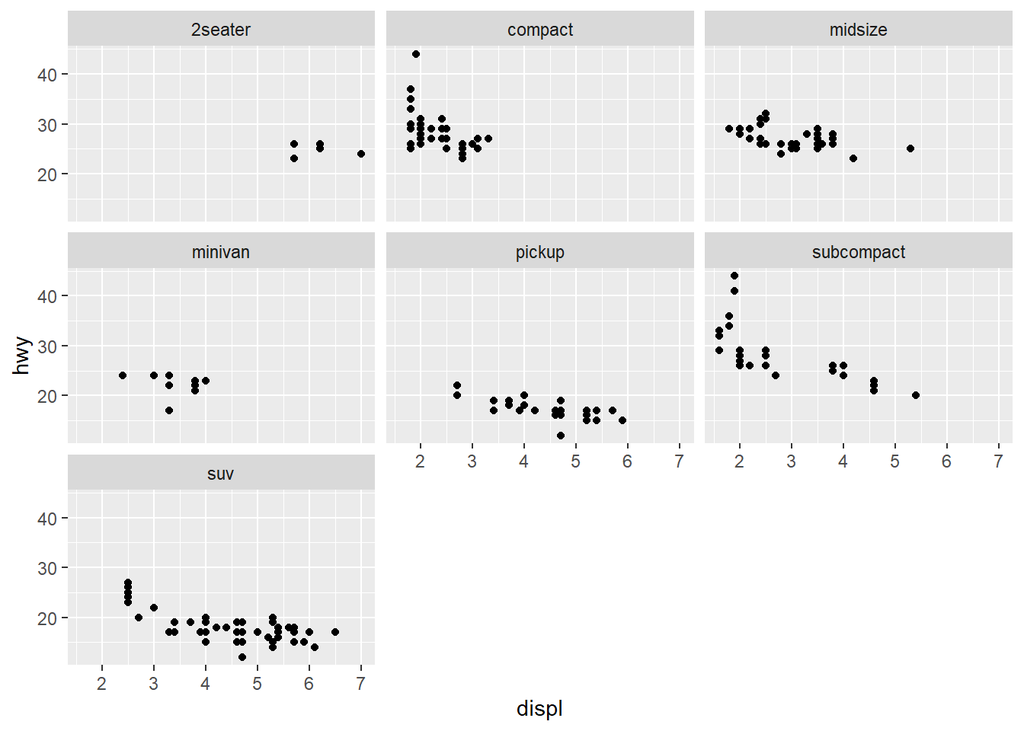

```r
ggplot(mpg, aes(displ, hwy)) +
  geom_point() +
  facet_wrap(~class)
```

### 1.5.1 Latihan

1. Apa yang terjadi jika Anda mencoba melakukan facet dengan variabel kontinu seperti `hwy`? Bagaimana dengan `cyl`? Apa perbedaan utamanya?
2. Gunakan faceting untuk mengeksplorasi hubungan tiga arah antara efisiensi bahan bakar, ukuran mesin, dan jumlah silinder. Bagaimana faceting berdasarkan jumlah silinder mengubah penilaian Anda terhadap hubungan antara ukuran mesin dan efisiensi bahan bakar?
3. Baca dokumentasi untuk `facet_wrap()`. Argumen apa yang dapat Anda gunakan untuk mengontrol jumlah baris dan kolom yang muncul dalam output?
4. Apa gunanya `scales` argumen tersebut `facet_wrap()`? Kapan Anda bisa menggunakannya?

## 1.6 Plot Geom

Anda mungkin menduga bahwa dengan mengganti `geom_point()` fungsi geom yang berbeda, Anda akan mendapatkan jenis plot yang berbeda. Tebakan yang bagus! Di bagian selanjutnya, Anda akan mempelajari beberapa geom penting lainnya yang disediakan di ggplot2. Daftar ini tidak lengkap, tetapi seharusnya mencakup jenis plot yang paling umum digunakan.

- `geom_smooth()` menyesuaikan penghalus dengan data dan menampilkan penghalus dan kesalahan standarnya.
- `geom_boxplot()` menghasilkan diagram kotak dan kumis untuk meringkas distribusi sekumpulan titik.
- `geom_histogram()` dan `geom_freqpoly()` menunjukkan distribusi variabel kontinu.
- `geom_bar(`)menunjukkan distribusi variabel kategoris.
- `geom_path()` dan `geom_line()` menggambar garis di antara titik-titik data. Plot garis dibatasi untuk menghasilkan garis yang bergerak dari kiri ke kanan, sementara jalur dapat bergerak ke segala arah. Garis biasanya digunakan untuk mengeksplorasi bagaimana sesuatu berubah seiring waktu.

### 1.6.1 Menambahkan Penghalus ke Plot

Jika Anda memiliki diagram sebar dengan banyak noise, pola dominannya mungkin sulit terlihat. Dalam hal ini, menambahkan garis halus ke diagram dengan `geom_smooth()`:

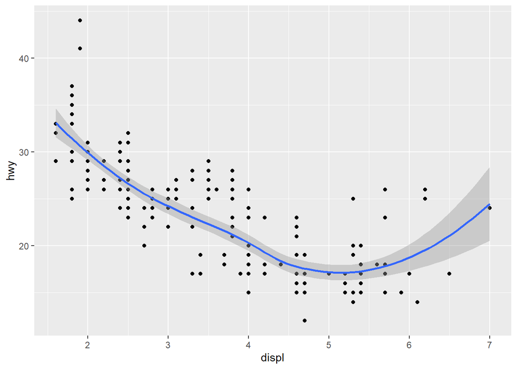

```r
ggplot(mpg, aes(displ, hwy)) +
  geom_point() +
  geom_smooth()
```

Ini melapisi diagram sebar dengan kurva halus, termasuk penilaian ketidakpastian dalam bentuk interval keyakinan per poin yang ditampilkan dalam warna abu-abu. Jika Anda tidak tertarik dengan interval keyakinan, nonaktifkan dengan `geom_smooth(se = FALSE)`.

Argumen penting untuk `geom_smooth()` adalah `method`, yang memungkinkan Anda memilih jenis model mana yang digunakan untuk menyesuaikan kurva halus:

- `method = "loess"`, nilai default untuk n kecil, menggunakan regresi lokal yang halus (seperti yang dijelaskan dalam `?loess`). Kemiringan garis dikontrol oleh `span` parameter, yang berkisar dari 0 (sangat bergelombang) hingga 1 (tidak terlalu bergelombang).

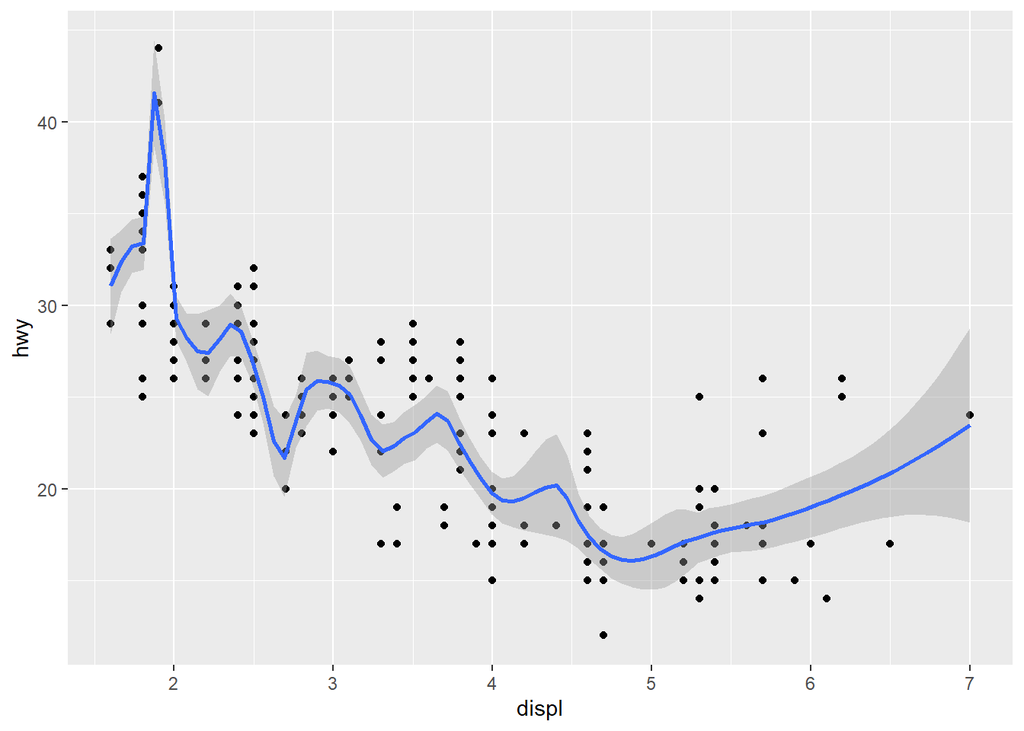

```r
ggplot(mpg, aes(displ, hwy)) +
  geom_point() +
  geom_smooth(span = 0.2)
```

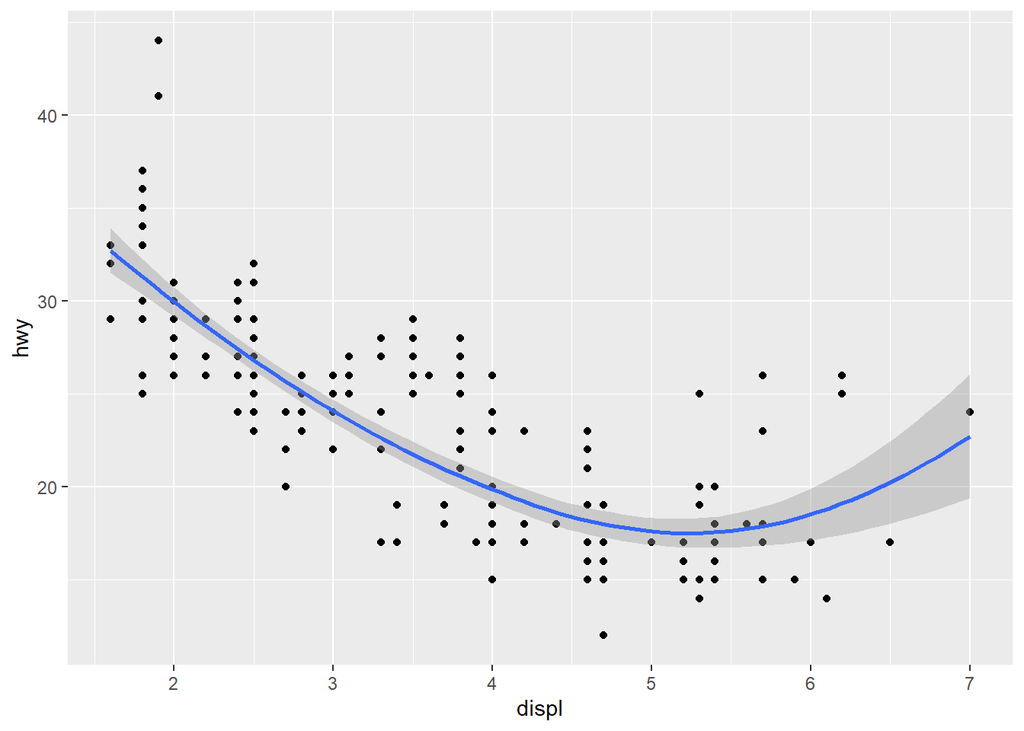

```r
ggplot(mpg, aes(displ, hwy)) +
  geom_point() +
  geom_smooth(span = 1)
```

Loess tidak bekerja dengan baik untuk kumpulan data besar (itu O(n2) dalam memori), jadi algoritma penghalusan alternatif digunakan saat n lebih besar dari 1.000.

- `method = "gam"` Sesuai dengan model aditif umum yang disediakan oleh paket **mgcv** . Anda perlu memuat mgcv terlebih dahulu, lalu menggunakan rumus seperti `formula = y ~ s(x)` atau `y ~ s(x, bs = "cs")` (untuk data besar). Inilah yang digunakan ggplot2 ketika terdapat lebih dari 1.000 titik.

```r
library(mgcv)
```

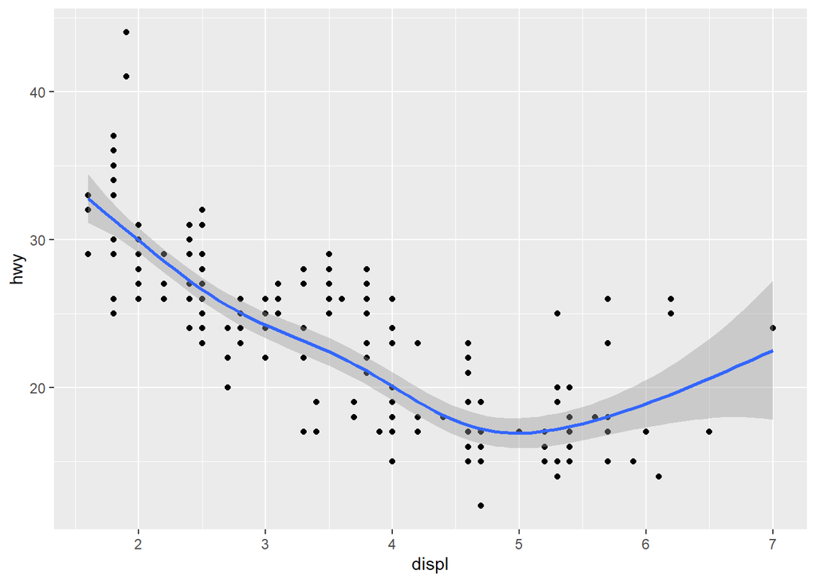

```r
ggplot(mpg, aes(displ, hwy)) +
  geom_point() +
  geom_smooth(method = "gam", formula = y ~ s(x))
```

- `method = "lm"` sesuai dengan model linier, memberikan garis yang paling sesuai.

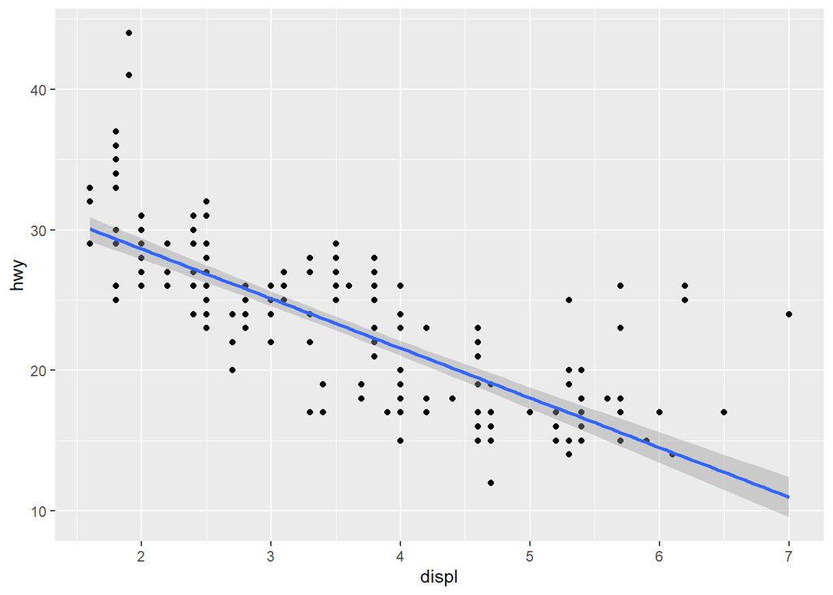

```r
ggplot(mpg, aes(displ, hwy)) +
  geom_point() +
  geom_smooth(method = "lm")
```

- `method = "rlm"` Berfungsi seperti `lm()`, tetapi menggunakan algoritma pemasangan yang robust sehingga outlier tidak terlalu memengaruhi hasil pemasangan. Ini adalah bagian dari paket **MASS** , jadi ingatlah untuk memuatnya terlebih dahulu.

### 1.6.2 Boxplot dan Titik-Titik Yang Bergetar

Ketika sekumpulan data mencakup satu variabel kategoris dan satu atau lebih variabel kontinu, Anda mungkin tertarik untuk mengetahui bagaimana nilai variabel kontinu tersebut bervariasi seiring dengan level variabel kategoris. Katakanlah kita ingin melihat bagaimana efisiensi bahan bakar bervariasi pada mobil dengan jenis drivetrain yang sama. Kita bisa mulai dengan diagram sebar seperti ini:

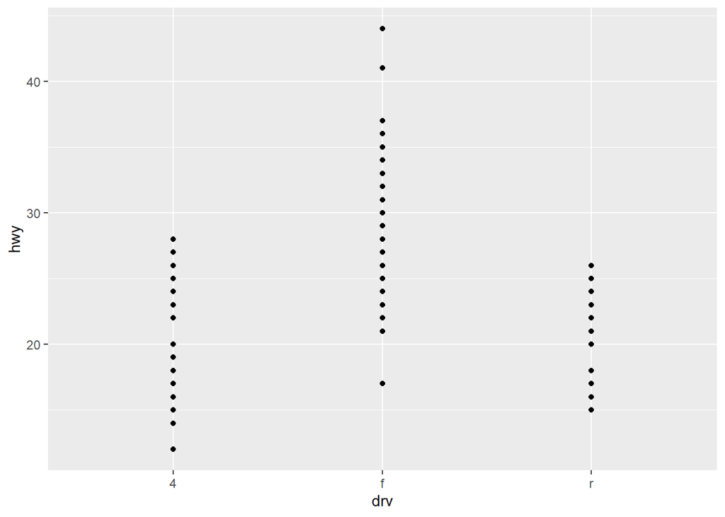

```r
ggplot(mpg, aes(drv, hwy)) +
  geom_point()
```

Karena hanya ada sedikit nilai unik untuk keduanya `drv` dan `hwy`, terjadi banyak overplotting. Banyak titik diplot di lokasi yang sama, sehingga distribusinya sulit dilihat. Ada tiga teknik bermanfaat yang dapat membantu mengatasi masalah ini: - Jittering, `geom_jitter()` menambahkan sedikit noise acak ke data yang dapat membantu menghindari overplotting. - Boxplot `geom_boxplot()`, meringkas bentuk distribusi dengan beberapa statistik ringkasan. - Plot biola, `geom_violin()`, menunjukkan representasi kompak dari “kepadatan” distribusi, yang menyorot area di mana lebih banyak titik ditemukan.

Berikut ini diilustrasikan:

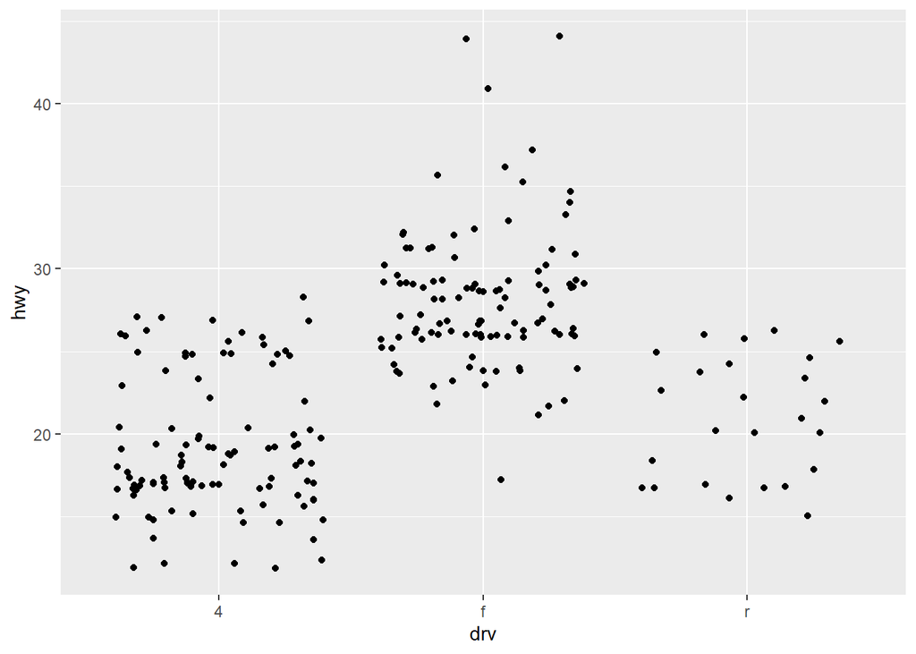

```r
ggplot(mpg, aes(drv, hwy)) + geom_jitter()
```

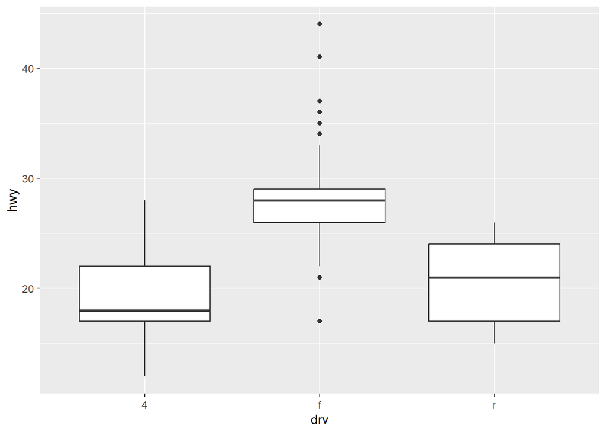

```r
ggplot(mpg, aes(drv, hwy)) + geom_boxplot()
```

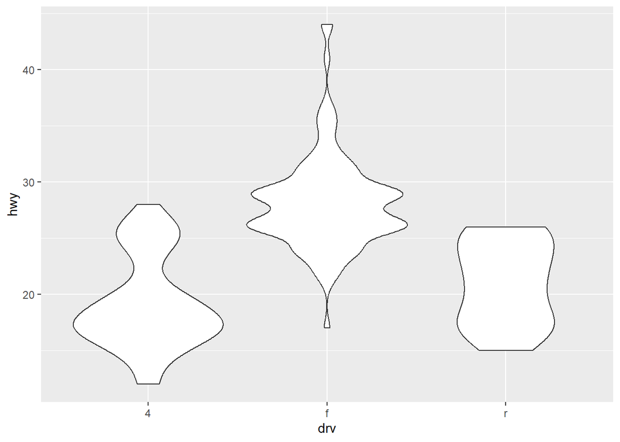

```r
ggplot(mpg, aes(drv, hwy)) + geom_violin()
```

Setiap metode memiliki kelebihan dan kekurangannya masing-masing. Boxplot merangkum sebagian besar distribusi hanya dengan lima angka, sementara jittered plot menunjukkan setiap titik tetapi hanya berfungsi dengan kumpulan data yang relatif kecil. Violin plot memberikan tampilan yang paling kaya, tetapi bergantung pada perhitungan estimasi kepadatan, yang mungkin sulit diinterpretasikan.

Untuk titik-titik yang bergetar, `geom_jitter()` menawarkan kontrol estetika yang sama seperti `geom_point()`: `size`, `colour`, dan `shape`. Untuk `geom_boxplot()`dan `geom_violin()`, Anda dapat mengontrol garis luar `colour` atau warna internal `fill`.

### 1.6.3 Histogram dan Poligon Frekuensi

Histogram dan poligon frekuensi menunjukkan distribusi satu variabel numerik. Histogram dan poligon frekuensi memberikan informasi lebih banyak tentang distribusi satu kelompok dibandingkan diagram kotak, dengan mengorbankan kebutuhan ruang yang lebih besar.

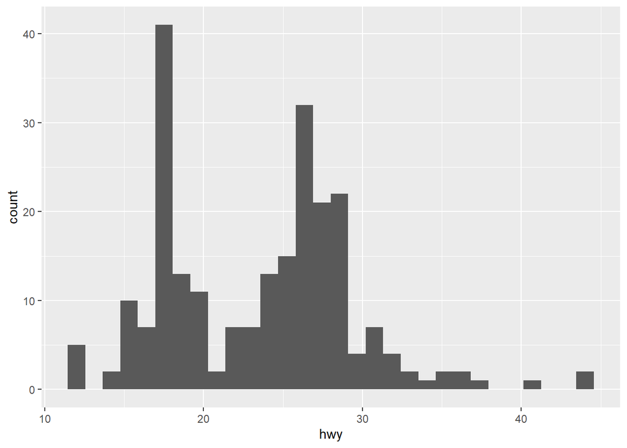

```r
ggplot(mpg, aes(hwy)) + geom_histogram()
```

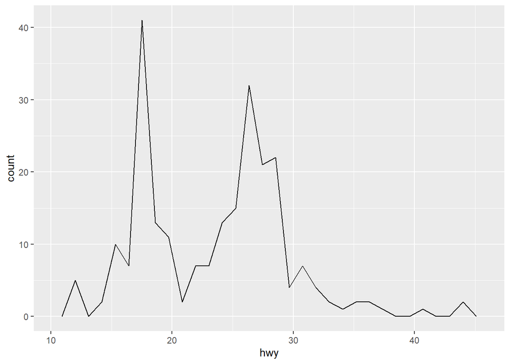

```r
ggplot(mpg, aes(hwy)) + geom_freqpoly()
```

Histogram dan poligon frekuensi bekerja dengan cara yang sama: keduanya mengelompokkan data, lalu menghitung jumlah observasi dalam setiap pengelompokkan. Satu-satunya perbedaan adalah tampilannya: histogram menggunakan batang, sedangkan poligon frekuensi menggunakan garis.

Anda dapat mengontrol lebar bin dengan `binwidt` hargumen (jika Anda tidak ingin bin dengan jarak yang sama, Anda dapat menggunakan `breaks` argumen). Sangat **penting** untuk bereksperimen dengan lebar bin. Pengaturan default hanya membagi data Anda menjadi 30 bin, yang kemungkinan besar bukan pilihan terbaik. Anda sebaiknya selalu mencoba berbagai lebar bin, dan Anda mungkin perlu beberapa lebar bin untuk mendapatkan gambaran lengkap tentang data Anda.

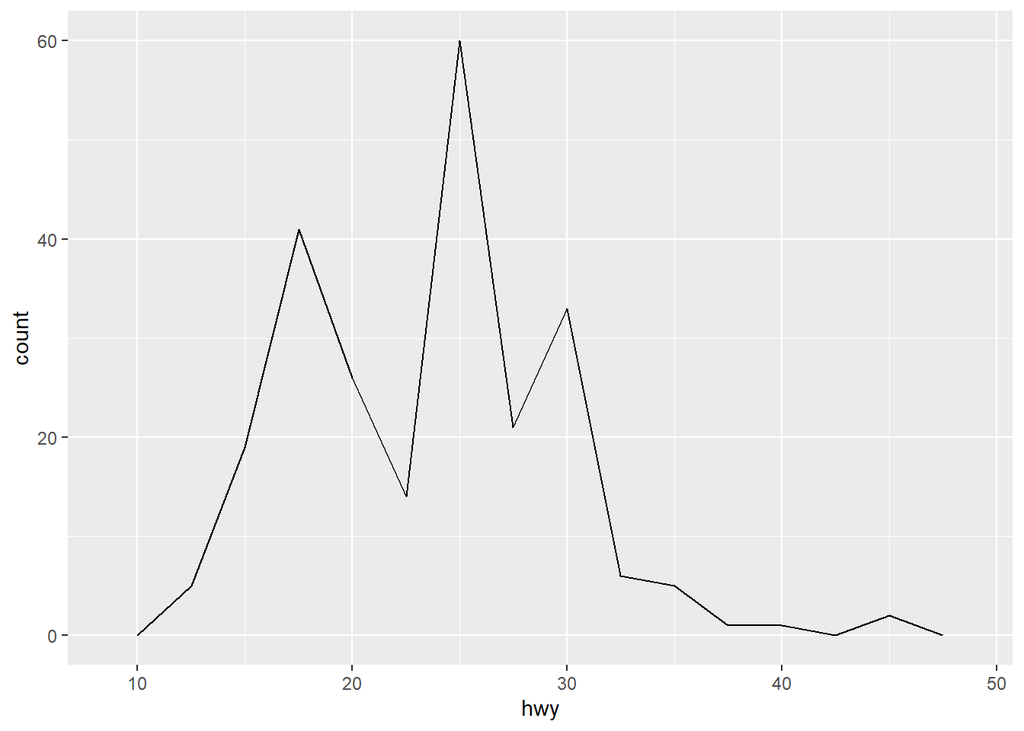

```r
ggplot(mpg, aes(hwy)) +
  geom_freqpoly(binwidth = 2.5)
```

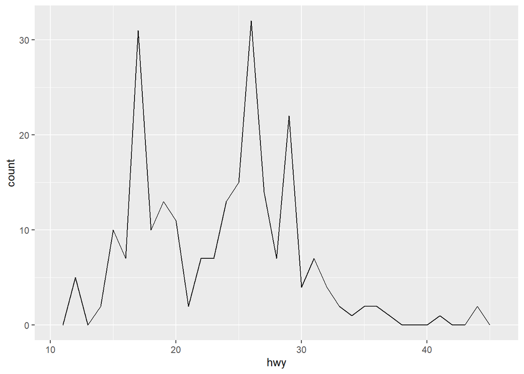

```r
ggplot(mpg, aes(hwy)) +
  geom_freqpoly(binwidth = 1)
```

Alternatif untuk poligon frekuensi adalah plot kepadatan. `geom_density()` Kehati-hatian diperlukan jika Anda menggunakan plot kepadatan: dibandingkan dengan poligon frekuensi, plot kepadatan lebih sulit diinterpretasikan karena perhitungan yang mendasarinya lebih kompleks. Plot kepadatan juga menggunakan asumsi yang tidak berlaku untuk semua data, yaitu bahwa distribusi yang mendasarinya kontinu, tak terbatas, dan halus.

Untuk membandingkan distribusi berbagai subgrup, Anda dapat memetakan variabel kategoris ke isian (untuk `geom_histogram()`) atau warna (untuk `geom_freqpoly()`). Membandingkan distribusi menggunakan poligon frekuensi lebih mudah karena tugas persepsi yang mendasarinya lebih mudah.Anda juga dapat menggunakan faceting: ini membuat perbandingan sedikit lebih sulit, tetapi lebih mudah untuk melihat distribusi setiap grup.

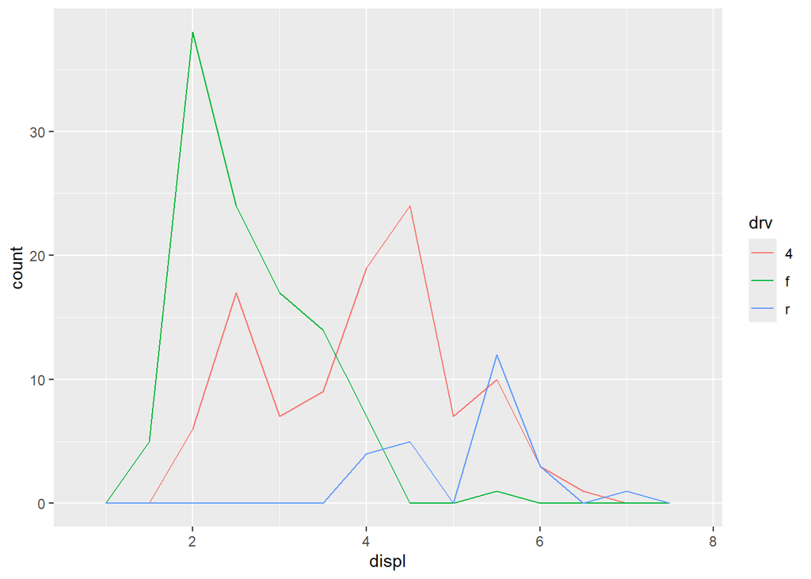

```r
ggplot(mpg, aes(displ, colour = drv)) +
  geom_freqpoly(binwidth = 0.5)
```

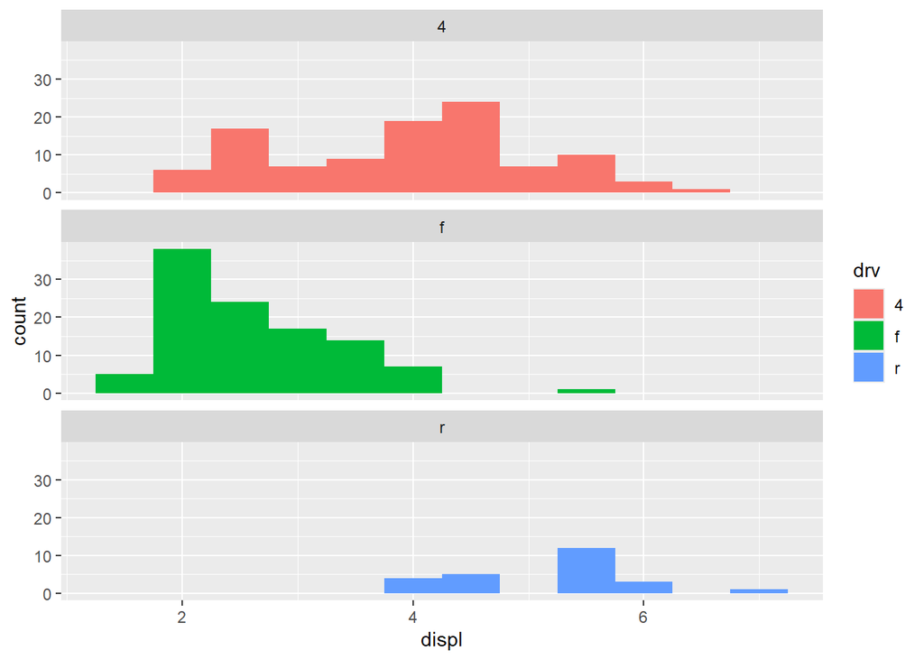

```r
ggplot(mpg, aes(displ, fill = drv)) +
  geom_histogram(binwidth = 0.5) +
  facet_wrap(~drv, ncol = 1)
```

### 1.6.4 Grafik Batang

Analog diskrit dari histogram adalah diagram batang. geom_bar()Mudah digunakan:

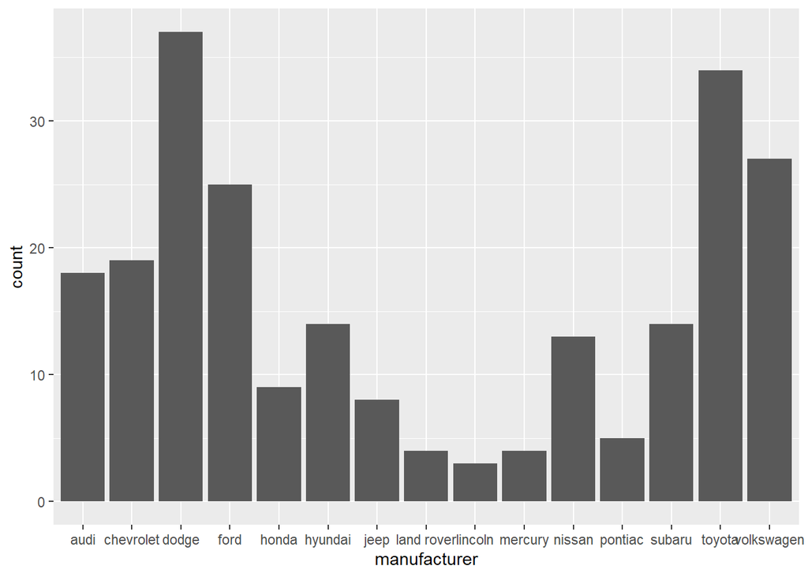

```r
ggplot(mpg, aes(manufacturer)) +
  geom_bar()
```

Diagram batang bisa membingungkan karena terdapat dua plot yang agak berbeda, yang keduanya biasa disebut diagram batang. Bentuk di atas mengharuskan Anda memiliki data yang belum diringkas, dan setiap observasi berkontribusi satu unit pada tinggi setiap batang. Bentuk diagram batang yang lain digunakan untuk data yang telah diringkas sebelumnya. Misalnya, Anda mungkin memiliki tiga obat dengan efek rata-ratanya:

```r
drugs <- data.frame(
  drug = c("a", "b", "c"),
  effect = c(4.2, 9.7, 6.1)
)
```

Untuk menampilkan data semacam ini, Anda perlu mengatur `geom_bar()`agar tidak menjalankan stat default yang mengelompokkan dan menghitung data. Namun, menurut kami, penggunaan stat ini lebih baik `geom_point()` karena titik membutuhkan ruang lebih sedikit daripada batang, dan tidak mengharuskan sumbu y memuat angka 0.

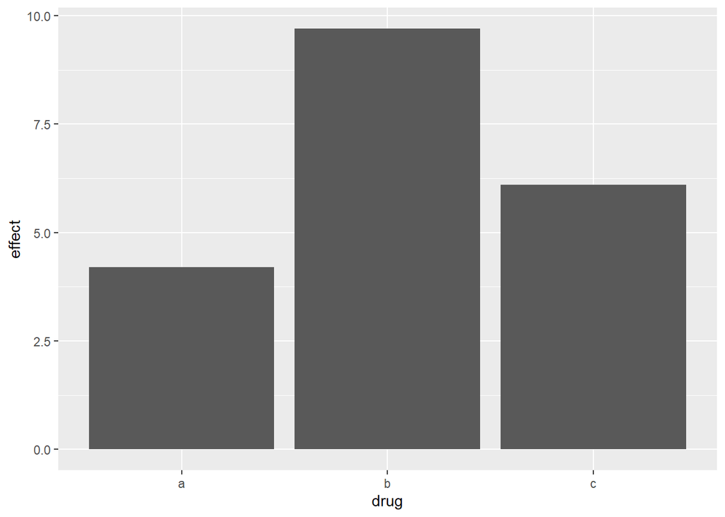

```r
ggplot(drugs, aes(drug, effect)) + geom_bar(stat = "identity")
```

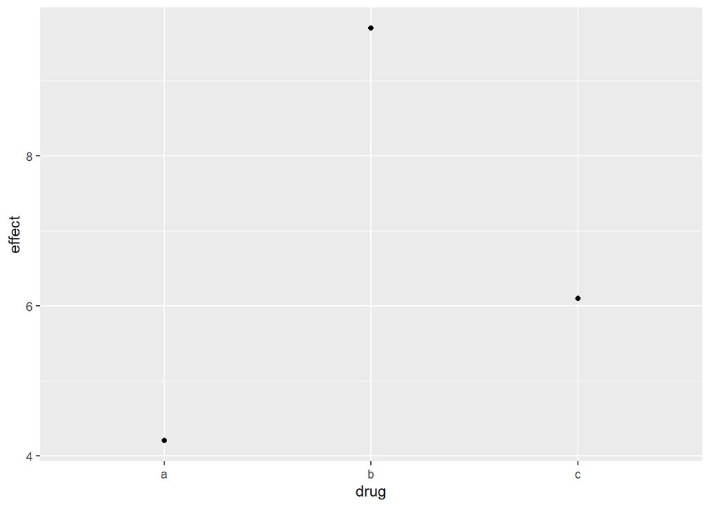

```r
ggplot(drugs, aes(drug, effect)) + geom_point()
```

### 1.6.5 Deret Waktu Dengan PLot Garis dan Jalur

Plot garis dan jalur biasanya digunakan untuk data deret waktu. Plot garis menghubungkan titik-titik dari kiri ke kanan, sementara plot jalur menghubungkannya sesuai urutan kemunculannya dalam set data (dengan kata lain, plot garis adalah plot jalur data yang diurutkan berdasarkan nilai x). Plot garis biasanya memiliki waktu pada sumbu x, yang menunjukkan bagaimana satu variabel tunggal berubah seiring waktu. Plot jalur menunjukkan bagaimana dua variabel berubah secara bersamaan seiring waktu, dengan waktu dikodekan dalam cara pengamatan dihubungkan.

Karena variabel tahun dalam `mpg` kumpulan data hanya memiliki dua nilai, kami akan menampilkan beberapa plot deret waktu menggunakan `economics` kumpulan data tersebut, yang berisi data ekonomi AS yang diukur selama 40 tahun terakhir. Gambar di bawah ini menunjukkan dua plot pengangguran dari waktu ke waktu, keduanya dihasilkan menggunakan `geom_line()`. Plot pertama menunjukkan tingkat pengangguran, sementara plot kedua menunjukkan median jumlah minggu pengangguran. Kita sudah dapat melihat beberapa perbedaan pada kedua variabel ini, terutama pada puncak terakhir, di mana persentase pengangguran lebih rendah daripada puncak sebelumnya, tetapi durasi penganggurannya tinggi.

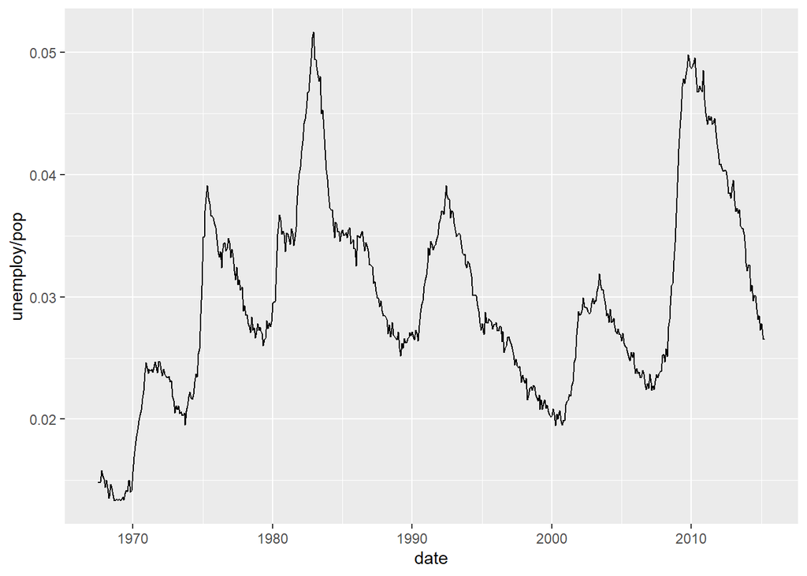

```r
ggplot(economics, aes(date, unemploy / pop)) +
  geom_line()
```

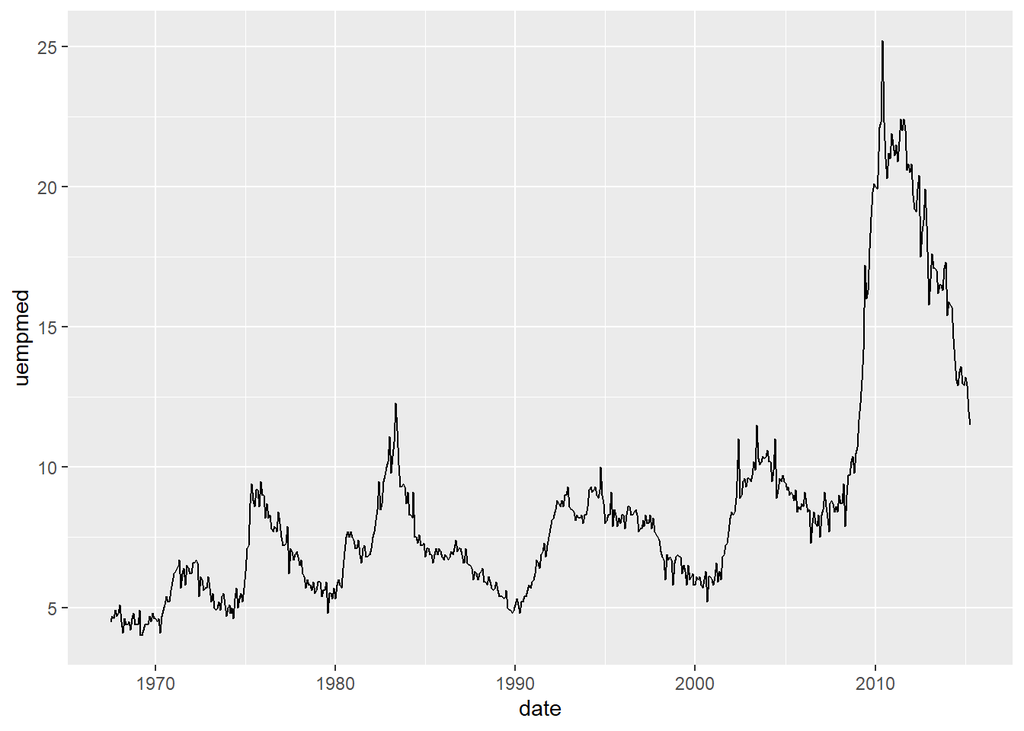

```r
ggplot(economics, aes(date, uempmed)) +
  geom_line()
```

Untuk memeriksa hubungan ini secara lebih rinci, kami ingin menggambar kedua deret waktu pada plot yang sama. Kami dapat menggambar diagram sebar tingkat pengangguran vs. lama pengangguran, tetapi dengan begitu kami tidak dapat lagi melihat perkembangannya seiring waktu. Solusinya adalah menghubungkan titik-titik yang berdekatan dalam waktu dengan segmen garis, membentuk plot *jalur* .

Di bawah ini, kami memplot tingkat pengangguran vs. lama pengangguran dan menghubungkan masing-masing observasi dengan sebuah jalur. Karena banyaknya garis yang bersilangan, arah aliran waktu tidak mudah terlihat pada plot pertama. Pada plot kedua, kami mewarnai titik-titik agar lebih mudah melihat arah waktu.

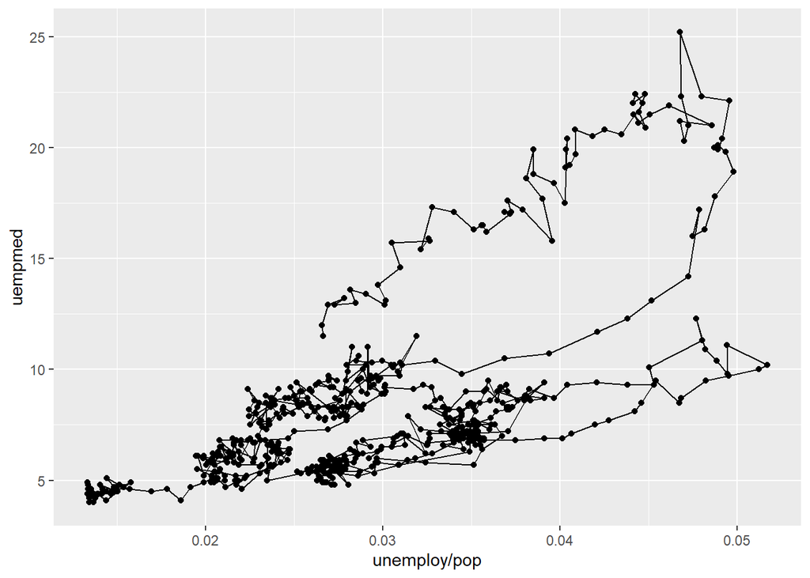

```r
ggplot(economics, aes(unemploy / pop, uempmed)) +
  geom_path() +
  geom_point()
```

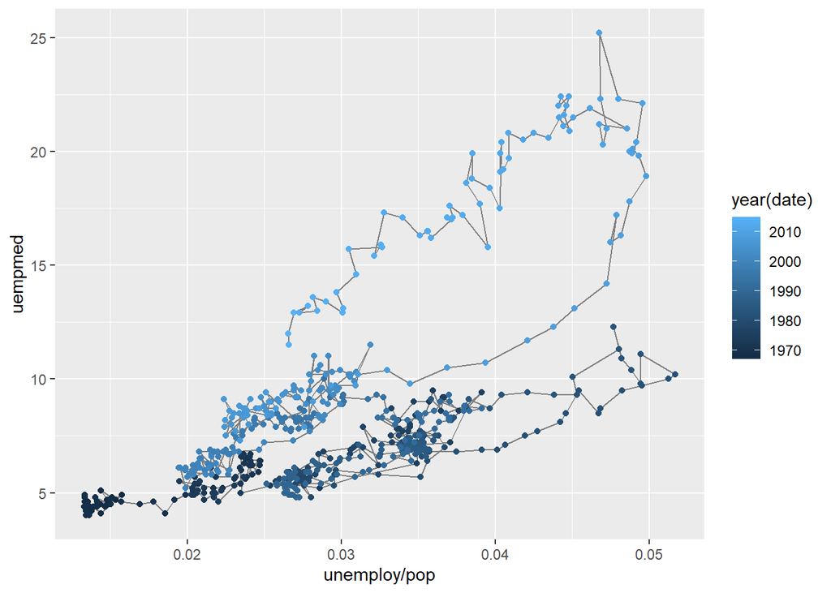

```r
year <- function(x) as.POSIXlt(x)$year + 1900
ggplot(economics, aes(unemploy / pop, uempmed)) +
  geom_path(colour = "grey50") +
  geom_point(aes(colour = year(date)))
```

Kita dapat melihat bahwa tingkat pengangguran dan lamanya pengangguran sangat berkorelasi, tetapi dalam beberapa tahun terakhir, lamanya pengangguran telah meningkat relatif terhadap tingkat pengangguran.

Dengan data longitudinal, Anda sering kali ingin menampilkan beberapa deret waktu pada setiap plot, dengan setiap deret mewakili satu individu. Untuk melakukannya, Anda perlu memetakan estetika groupke variabel yang mengodekan keanggotaan grup setiap observasi.

### 1.6.6 Latihan

1. Apa masalah dengan plot yang dibuat oleh `ggplot(mpg, aes(cty, hwy)) + geom_point()`? Geom mana yang dijelaskan di atas yang paling efektif dalam mengatasi masalah tersebut?
2. Salah satu tantangannya `ggplot(mpg, aes(class, hwy)) + geom_boxplot()`adalah pengurutan `class` berdasarkan abjad, yang kurang bermanfaat. Bagaimana Anda bisa mengubah tingkat faktor agar lebih informatif?

Daripada menyusun ulang faktor secara manual, Anda dapat melakukannya secara otomatis berdasarkan data: `ggplot(mpg, aes(reorder(class, hwy), hwy)) + geom_boxplot()`. Apa fungsinya `reorder()`? Baca dokumentasinya. 3. Jelajahi distribusi variabel karat dalam `diamonds` kumpulan data. Lebar bin berapa yang menunjukkan pola paling menarik? 4. Jelajahi distribusi variabel harga dalam `diamonds` data. Bagaimana distribusinya bervariasi berdasarkan potongan? 5. Anda sekarang mengetahui (setidaknya) tiga cara untuk membandingkan distribusi subgrup: `geom_violin()`, `geom_freqpoly()` dan estetika warna, atau `geom_histogram()` dan faceting. Apa saja kekuatan dan kelemahan masing-masing pendekatan? Pendekatan lain apa yang bisa Anda coba? 6. Baca dokumentasi untuk `geom_bar()`. Apa `weight` fungsi estetika? 7. Dengan menggunakan teknik yang telah dibahas dalam bab ini, temukan tiga cara untuk memvisualisasikan distribusi kategoris 2D. Cobalah dengan memvisualisasikan distribusi `model` dan `manufacturer`, `trans` dan `class`, dan `cyl` dan `trans`.

## 1.7 Memodifikasi Sumbu

Anda akan mempelajari seluruh rangkaian opsi yang tersedia di bab-bab selanjutnya, tetapi dua keluarga pembantu yang berguna memungkinkan Anda membuat modifikasi yang paling umum `xlab()` dan `ylab()` memodifikasi label sumbu x dan y:

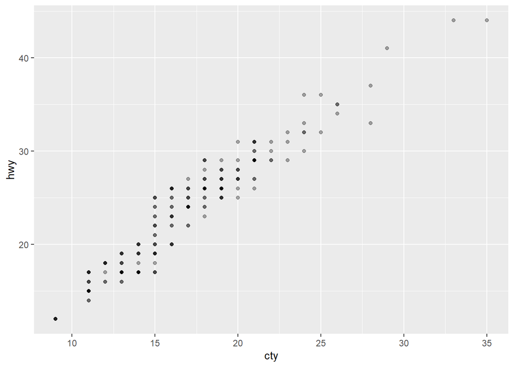

```r
ggplot(mpg, aes(cty, hwy)) +
  geom_point(alpha = 1 / 3)
```

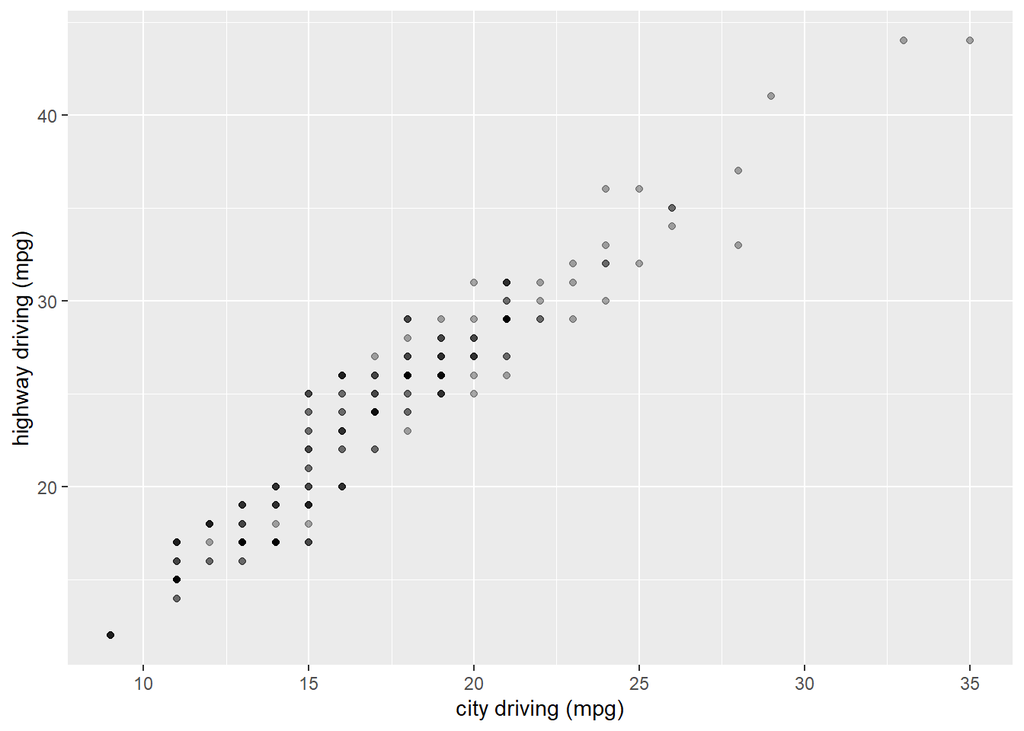

```r
ggplot(mpg, aes(cty, hwy)) +
  geom_point(alpha = 1 / 3) +
  xlab("city driving (mpg)") +
  ylab("highway driving (mpg)")
```

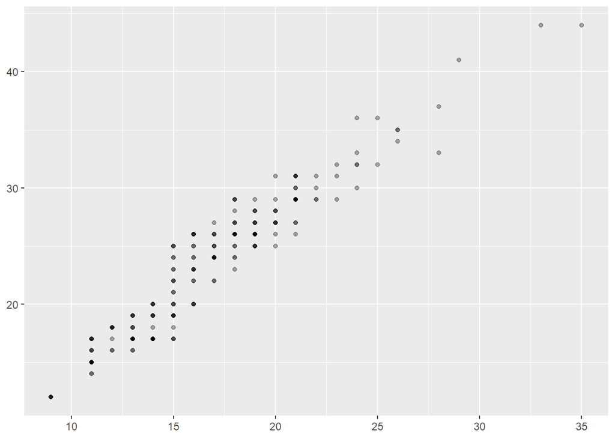

```r
# Remove the axis labels with NULL
ggplot(mpg, aes(cty, hwy)) +
  geom_point(alpha = 1 / 3) +
  xlab(NULL) +
  ylab(NULL)
```

`xlim()` dan `ylim()` memodifikasi batas sumbu:

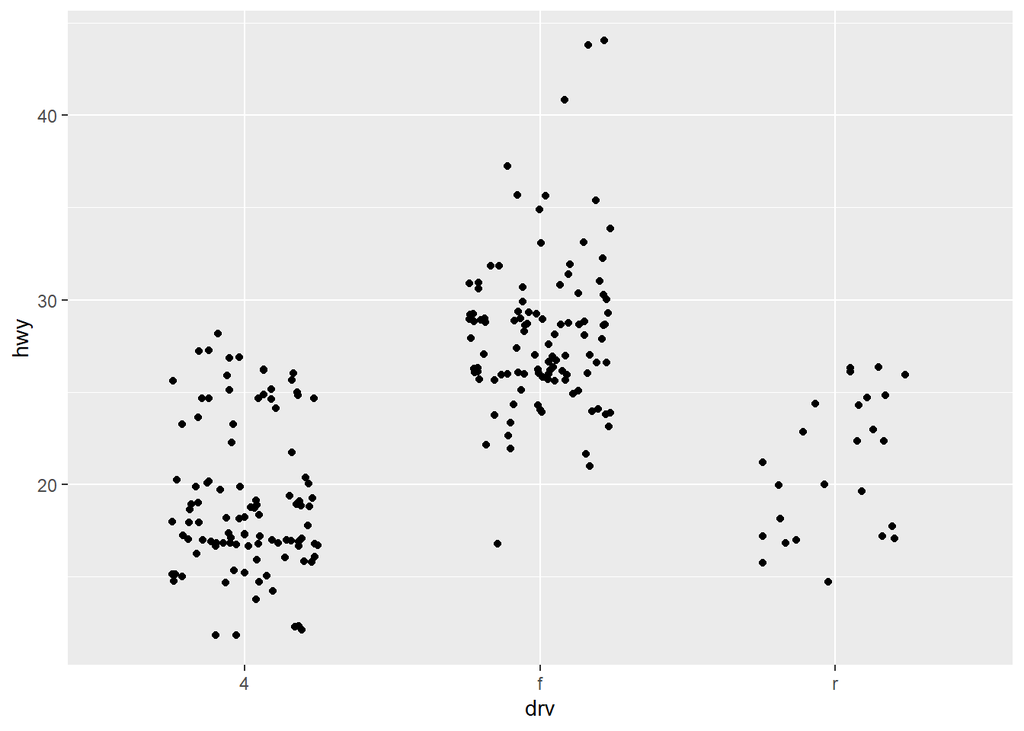

```r
ggplot(mpg, aes(drv, hwy)) +
  geom_jitter(width = 0.25)
```

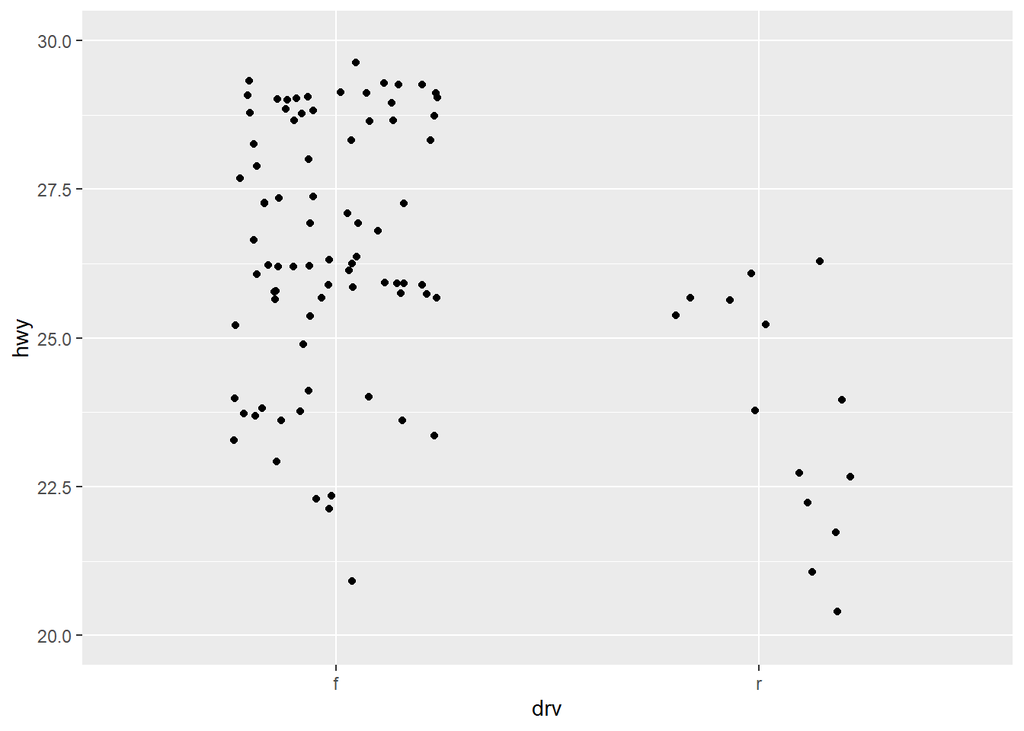

```
#> Warning: Removed 138 rows containing missing values or values outside the scale range
#> (`geom_point()`).
```

```r
ggplot(mpg, aes(drv, hwy)) +
  geom_jitter(width = 0.25) +
  xlim("f", "r") +
  ylim(20, 30)
```

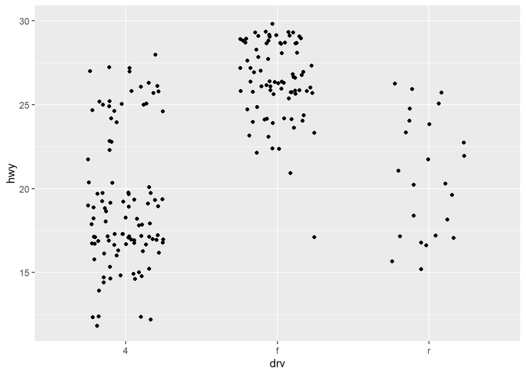

```r
# For continuous scales, use NA to set only one limit
ggplot(mpg, aes(drv, hwy)) +
  geom_jitter(width = 0.25, na.rm = TRUE) +
  ylim(NA, 30)
```

Mengubah batas sumbu akan menetapkan nilai di luar rentang ke `NA`. Anda dapat menonaktifkan peringatan terkait dengan `na.rm = TRUE`, tetapi berhati-hatilah. Jika plot Anda menghitung statistik ringkasan (misalnya, rata-rata sampel), konversi ke ini `NA` terjadi *sebelum* statistik ringkasan dihitung, dan dapat menyebabkan hasil yang tidak diinginkan dalam beberapa situasi.

## 1.8 Keluaran

Sering kali Anda membuat objek plot dan langsung memplotnya, tetapi Anda juga dapat menyimpan plot ke variabel dan memanipulasinya:

```r
p <- ggplot(mpg, aes(displ, hwy, colour = factor(cyl))) +
  geom_point()
```

Setelah Anda memiliki objek plot, ada beberapa hal yang dapat Anda lakukan dengannya:

Render di layar dengan `print()`. Ini terjadi secara otomatis saat dijalankan secara interaktif, tetapi di dalam loop atau fungsi, Anda perlu melakukannya `print()` sendiri.

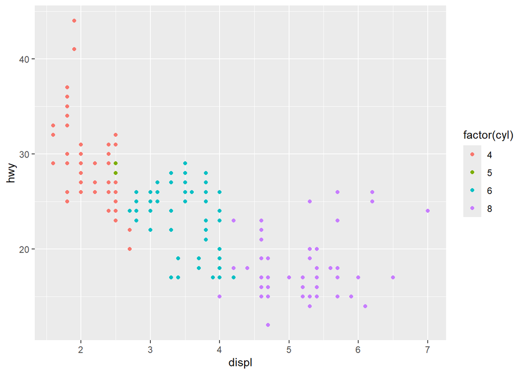

```r
print(p)
```

- Simpan ke disk dengan `ggsave()`

```r
# Save png to disk
ggsave("plot.png", p, width = 5, height = 5)
```

- Jelaskan secara singkat strukturnya dengan `summary()`

```r
summary(p)
```

```
## data: manufacturer, model, displ, year, cyl, trans, drv, cty, hwy, fl,
##   class [234x11]
## mapping:  x = ~displ, y = ~hwy, colour = ~factor(cyl)
## faceting:  <empty>
## -----------------------------------
## geom_point: na.rm = FALSE
## stat_identity: na.rm = FALSE
## position_identity
```

```
#> data: manufacturer, model, displ, year, cyl, trans, drv, cty, hwy, fl,
#>   class [234x11]
#> mapping:  x = ~displ, y = ~hwy, colour = ~factor(cyl)
#> faceting:  <empty>
#> -----------------------------------
#> geom_point: na.rm = FALSE
#> stat_identity: na.rm = FALSE
#> position_identity
```

DONE.